# Week 10 Day 5 - Homework

# Data Dictionary

index Date: The date of the observation AveragePrice: the average price of a single avocado Total Volume: Total number of avocados sold 4046: Total number of avocados with PLU 4046 sold 4225: Total number of avocados with PLU 4225 sold 4770: Total number of avocados with PLU 4770 sold Total Bags Small Bags Large Bags XLarge Bags type: conventional or organic year: the year region: the city or region of the observation

#1 MVP We’ve looked at a few different ways in which we can build models this week, including how to prepare them properly. This weekend we’ll build a multiple linear regression model on a dataset which will need some preparation. The data can be found in the data folder, along with a data dictionary

We want to investigate the avocado dataset, and, in particular, to model the AveragePrice of the avocados. Use the tools we’ve worked with this week in order to prepare your dataset and find appropriate predictors. Once you’ve built your model use the validation techniques discussed on Wednesday to evaluate it. Feel free to focus either on building an explanatory or a predictive model, or both if you are feeling energetic!

As part of the MVP we want you not to just run the code but also have a go at interpreting the results and write your thinking in comments in your script.

Hints and tips

region may lead to many dummy variables. Think carefully about whether to include this variable or not (there is no one ‘right’ answer to this!) Think about whether each variable is categorical or numerical. If categorical, make sure that the variable is represented as a factor. We will not treat this data as a time series, so Date will not be needed in your models, but can you extract any useful features out of Date before you discard it? If you want to build a predictive model, consider using either leaps or glmulti to help with this.

```r
library(tidyverse)
library(GGally)
library(ggfortify)
library(lubridate)
library(modelr)
```

```r
avocado <- read_csv(here::here("avocado.csv")) %>%
  janitor::clean_names()
```

# Data Exploration

```r
skimr::skim(avocado)
```

```r
head(avocado, 5)
```

```r
avocado %>%
  ggplot(aes(average_price)) +
  geom_histogram()
```

Average price looks as if it right skewed and so taking a logarithmic could help to create a slighly more normalised data set.

```r
avocado %>%
  ggplot(aes(x = log(average_price))) +
  geom_histogram()
```

Check for the unique values in each

```r
avocado %>%
  summarise(across(everything(), .fns = ~length(unique(.x))))
```

```r
avocado %>%
  mutate(across(.fns = ~replace(., duplicated(.), NA)))
```

Check to see if there are aliases within the data set.

```r
alias(average_price ~ ., data = avocado)
```

Whilst this did no appear in the above. Total bags is the summation of small, large and xl bags and so will be removed from the data set.

```r
avocado %>%
  mutate(check = total_bags - small_bags - large_bags - x_large_bags) %>%
  slice_max(check,n=5)
```

```r
# Does not appear that total volume is related to the x4* numbers
avocado %>%
  mutate(check = total_volume - x4046 - x4225 - x4770) %>%
  select(check, total_volume, contains("x4"))
```

```r
avocado %>%
  distinct(region)
```

```r
avocado %>%
  distinct(type)
```

# Data Engineering

```r
avocado_tidy <- avocado %>%
  mutate(month = month(date, label = TRUE),
         year = as.factor(year)) %>%
  select(-c(x1,date, total_bags, region)) %>%
  rename_with(~str_replace(.x, "x4", "plu_4"))
```

## Split in to training and validation

```r
test_index <- sample(1:nrow(avocado_tidy), size = nrow(avocado_tidy)*0.1)

avocado_train <- slice(avocado_tidy, -test_index)
avocado_test <- slice(avocado_tidy, test_index)
```

# Manual Model Creation

Function for easier plots later:

```r
ggpairs_plots <- function(data, main_columns){
  data %>%
    select(where(is.numeric), main_columns, type) %>%
    ggpairs(aes(colour = type), progress = FALSE) %>%
    print()

  data %>%
    select(-where(is.numeric), main_columns ,type) %>%
    ggpairs(aes(colour = type), progress = FALSE) %>%
    print()
}
```

Review the correlation of variables. From the initial look, there does not appear to be any clear correlation between average price and any of the other variables

```r
avocado_train %>%
  ggcorr(label = TRUE)

avocado_train %>%
  filter(type == "organic") %>%
  ggcorr(label = TRUE)

avocado_train %>%
  filter(type != "organic") %>%
  ggcorr(label = TRUE)
```

```r
avocado_train %>%
  ggpairs_plots(c("average_price"))
```

## Model 1

From the ggpairs plots the type has a large effect on the average price. The month also has an affect

### Type

```r
model_1_type <- lm(average_price ~ type,
                   data = avocado_train)

summary(model_1_type)
autoplot(model_1_type)
```

```r
model_1_type_log <- lm(log(average_price) ~ type,
                   data = avocado_train)

summary(model_1_type_log)
autoplot(model_1_type_log)
```

#### Discussion

The model with type seems to be statistically significant. The organic type will increase the average price by 0.495.

### total_volume

```r
model_1_tot_vol <- lm(average_price ~ total_volume,
                   data = avocado_train)

summary(model_1_tot_vol)
autoplot(model_1_tot_vol)
```

#### Discussion

Whilst the values are significant the r2 is lower than the type. There is also a large deviation in the residuals. The first group is no around 0, where the second group is mainly over presidcted.

### plu 4046

```r
model_1_plu4046 <- lm(average_price ~ plu_4046,
                   data = avocado_train)

summary(model_1_tot_vol)
autoplot(model_1_tot_vol)
```

#### Discussion

As per the total volume, the there is siginificance of plu_4046 bein in the model however, the r2 is currently low. Thereofre this will not be accepted at this time since the reidual plots are not acceptable.

> Model 1 champion = type

## Model 2

```r
avocado_train %>%
  add_residuals(model_1_type) %>%
  ggpairs_plots(c("average_price","resid"))
```

```r
test_index <- sample(1:nrow(avocado_tidy), size = nrow(avocado_tidy)*0.1)

avocado_train <- slice(avocado_tidy, -test_index)
avocado_test <- slice(avocado_tidy, test_index)
```

### month

```r
model_2_month <- lm(average_price ~ type + month,
                   data = avocado_train)
summary(model_2_month)
```

```
Call:
lm(formula = average_price ~ type + month, data = avocado_train)

Residuals:
     Min       1Q   Median       3Q      Max
-1.15131 -0.19578 -0.02037  0.18676  1.54599

Coefficients:
             Estimate Std. Error t value Pr(>|t|)
(Intercept)  1.166771   0.003342 349.121  < 2e-16 ***
typeorganic  0.496687   0.004713 105.393  < 2e-16 ***
month.L      0.215435   0.008034  26.815  < 2e-16 ***
month.Q     -0.153696   0.008151 -18.855  < 2e-16 ***
month.C     -0.187972   0.008142 -23.087  < 2e-16 ***
month^4     -0.073766   0.008092  -9.116  < 2e-16 ***
month^5     -0.011188   0.008200  -1.364 0.172461
month^6      0.062489   0.008306   7.524 5.61e-14 ***
month^7     -0.005788   0.008126  -0.712 0.476316
month^8      0.029697   0.008154   3.642 0.000271 ***
month^9      0.010830   0.008368   1.294 0.195612
month^10    -0.022990   0.008406  -2.735 0.006246 **
month^11     0.014571   0.008459   1.723 0.084968 .
---
Signif. codes:  0 ‘***’ 0.001 ‘**’ 0.01 ‘*’ 0.05 ‘.’ 0.1 ‘ ’ 1

Residual standard error: 0.302 on 16412 degrees of freedom
Multiple R-squared:  0.4399,    Adjusted R-squared:  0.4395
F-statistic:  1074 on 12 and 16412 DF,  p-value: < 2.2e-16
```

```r
autoplot(model_2_month)
```

```r
anova(model_1_type, model_2_month)
```

```
Analysis of Variance Table

Model 1: average_price ~ type
Model 2: average_price ~ type + month
  Res.Df    RSS Df Sum of Sq      F    Pr(>F)
1  16423 1657.8
2  16412 1496.7 11    161.09 160.59 < 2.2e-16 ***
---
Signif. codes:  0 ‘***’ 0.001 ‘**’ 0.01 ‘*’ 0.05 ‘.’ 0.1 ‘ ’ 1
```

```r
avocado_train %>%
  distinct(month) %>%
  pull()
```

```
 [1] Dec Nov Oct Sep Aug Jul Jun May Apr Mar Feb Jan
Levels: Jan < Feb < Mar < Apr < May < Jun < Jul < Aug < Sep < Oct < Nov < Dec
```

#### Discussion

The month has an increase in the r2 by about 5%. The residuals are still distributed around 0. However there is a slight increase in the trend of the residuals compared to the baseline model. Not all of the months have are significant however using anova, the overall inclusion of month is significant.

### year

```r
model_2_year <- lm(average_price ~ type + year,
                   data = avocado_train)
summary(model_2_year)
```

```
Call:
lm(formula = average_price ~ type + year, data = avocado_train)

Residuals:
     Min       1Q   Median       3Q      Max
-1.28633 -0.18633 -0.01633  0.18162  1.66147

Coefficients:
             Estimate Std. Error t value Pr(>|t|)
(Intercept)  1.128878   0.004978 226.791  < 2e-16 ***
typeorganic  0.497357   0.004815 103.298  < 2e-16 ***
year2016    -0.037707   0.006146  -6.135  8.7e-10 ***
year2017     0.140096   0.006105  22.947  < 2e-16 ***
year2018    -0.030500   0.010063  -3.031  0.00244 **
---
Signif. codes:  0 ‘***’ 0.001 ‘**’ 0.01 ‘*’ 0.05 ‘.’ 0.1 ‘ ’ 1

Residual standard error: 0.3085 on 16420 degrees of freedom
Multiple R-squared:  0.4151,    Adjusted R-squared:  0.4149
F-statistic:  2913 on 4 and 16420 DF,  p-value: < 2.2e-16
```

```r
autoplot(model_2_year)
```

### total_volume

```r
model_2_total_volume <- lm(average_price ~ type + total_volume,
                   data = avocado_train)
summary(model_2_total_volume)
```

```
Call:
lm(formula = average_price ~ type + total_volume, data = avocado_train)

Residuals:
     Min       1Q   Median       3Q      Max
-1.17654 -0.19951 -0.02684  0.18410  1.59324

Coefficients:
               Estimate Std. Error t value Pr(>|t|)
(Intercept)   1.170e+00  3.700e-03 316.211   <2e-16 ***
typeorganic   4.869e-01  5.086e-03  95.728   <2e-16 ***
total_volume -6.367e-09  7.414e-10  -8.588   <2e-16 ***
---
Signif. codes:  0 ‘***’ 0.001 ‘**’ 0.01 ‘*’ 0.05 ‘.’ 0.1 ‘ ’ 1

Residual standard error: 0.317 on 16422 degrees of freedom
Multiple R-squared:  0.3823,    Adjusted R-squared:  0.3823
F-statistic:  5083 on 2 and 16422 DF,  p-value: < 2.2e-16
```

```r
autoplot(model_2_total_volume)
```

### Discussion

The total volume provides some addition to the r2 however the effect is smaller than year and month. The addition is statistically significant based on the p-value. The total volume is decrease the cost by -6e9 for a unit volume when the type is kept constant.

> Champion model is month

```r
ggpairs_plots <- function(data, main_columns, remove_columns = "pleasenothing"){
  data %>%
    select(-any_of(remove_columns),  where(is.numeric), any_of(main_columns)) %>%
    ggpairs(aes(colour = type), progress = FALSE) %>%
    print()

  data %>%
    select(-any_of(remove_columns), -where(is.numeric), any_of(main_columns)) %>%
    ggpairs(aes(colour = type), progress = FALSE) %>%
    print()
}
```

## Model 3

[output not shown]

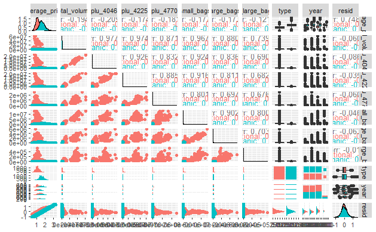

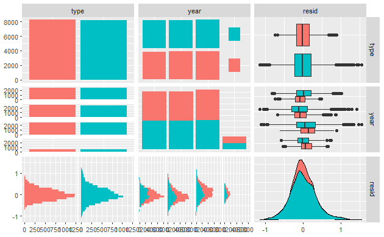

```r
avocado_train %>%
  add_residuals(model_2_month) %>%
  ggpairs_plots(main_columns = c("resid", "type"), remove_columns = c("month"))
```

### year

```r
model_3_year <- lm(average_price ~ type + month + year,
                   data = avocado_train)

summary(model_3_year)
```

```
Call:
lm(formula = average_price ~ type + month + year, data = avocado_train)

Residuals:
     Min       1Q   Median       3Q      Max
-1.20330 -0.18618 -0.01182  0.17797  1.49417

Coefficients:
             Estimate Std. Error t value Pr(>|t|)
(Intercept)  1.128696   0.004727 238.790  < 2e-16 ***
typeorganic  0.497060   0.004565 108.893  < 2e-16 ***
month.L      0.226350   0.008203  27.594  < 2e-16 ***
month.Q     -0.167281   0.008074 -20.719  < 2e-16 ***
month.C     -0.188865   0.007891 -23.934  < 2e-16 ***
month^4     -0.072326   0.007876  -9.183  < 2e-16 ***
month^5     -0.017783   0.007993  -2.225  0.02611 *
month^6      0.059965   0.008055   7.444 1.02e-13 ***
month^7     -0.004036   0.007878  -0.512  0.60845
month^8      0.023552   0.007923   2.973  0.00296 **
month^9      0.005446   0.008132   0.670  0.50302
month^10    -0.015819   0.008157  -1.939  0.05248 .
month^11     0.013101   0.008195   1.599  0.10991
year2016    -0.038490   0.005839  -6.592 4.47e-11 ***
year2017     0.140207   0.005808  24.142  < 2e-16 ***
year2018     0.084965   0.010391   8.176 3.13e-16 ***
---
Signif. codes:  0 ‘***’ 0.001 ‘**’ 0.01 ‘*’ 0.05 ‘.’ 0.1 ‘ ’ 1

Residual standard error: 0.2925 on 16409 degrees of freedom
Multiple R-squared:  0.4746,    Adjusted R-squared:  0.4741
F-statistic: 988.2 on 15 and 16409 DF,  p-value: < 2.2e-16
```

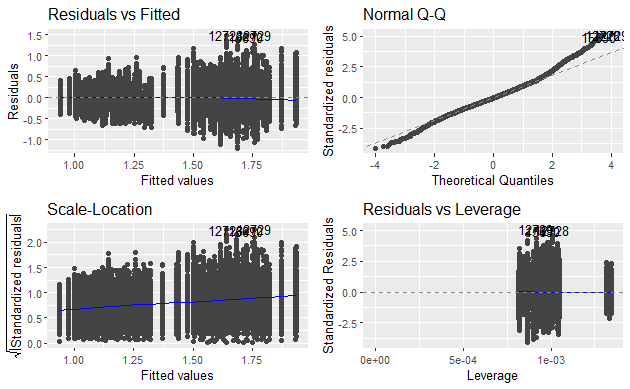

```r
autoplot(model_3_year)
```

```r
anova(model_2_month, model_3_year)
```

```
Analysis of Variance Table

Model 1: average_price ~ type + month
Model 2: average_price ~ type + month + year
  Res.Df    RSS Df Sum of Sq      F    Pr(>F)
1  16412 1496.7
2  16409 1403.8  3    92.876 361.87 < 2.2e-16 ***
---
Signif. codes:  0 ‘***’ 0.001 ‘**’ 0.01 ‘*’ 0.05 ‘.’ 0.1 ‘ ’ 1
```

#### Discussion

The addition of year does not impact the residual plots with the values still distributed around 0. There is still a small increase in the standadrdised residuals but this is small. The normal curve for the residuals is slightly right skewed. All of the years are shown to be of significance with an increase in the r2.

### total_volume

```r
model_3_tot_vol <- lm(average_price ~ type + month + total_volume,
                   data = avocado_train)

summary(model_3_tot_vol)
```

```
Call:
lm(formula = average_price ~ type + month + total_volume, data = avocado_train)

Residuals:
     Min       1Q   Median       3Q      Max
-1.15078 -0.19682 -0.01969  0.18815  1.54589

Coefficients:
               Estimate Std. Error t value Pr(>|t|)
(Intercept)   1.176e+00  3.528e-03 333.260  < 2e-16 ***
typeorganic   4.878e-01  4.836e-03 100.867  < 2e-16 ***
month.L       2.138e-01  8.022e-03  26.649  < 2e-16 ***
month.Q      -1.538e-01  8.136e-03 -18.902  < 2e-16 ***
month.C      -1.874e-01  8.127e-03 -23.054  < 2e-16 ***
month^4      -7.303e-02  8.077e-03  -9.041  < 2e-16 ***
month^5      -1.102e-02  8.185e-03  -1.347 0.178050
month^6       6.173e-02  8.291e-03   7.446 1.01e-13 ***
month^7      -5.142e-03  8.111e-03  -0.634 0.526133
month^8       2.986e-02  8.138e-03   3.669 0.000244 ***
month^9       1.094e-02  8.352e-03   1.310 0.190071
month^10     -2.269e-02  8.390e-03  -2.704 0.006854 **
month^11      1.432e-02  8.443e-03   1.696 0.089812 .
total_volume -5.602e-09  7.053e-10  -7.942 2.11e-15 ***
---
Signif. codes:  0 ‘***’ 0.001 ‘**’ 0.01 ‘*’ 0.05 ‘.’ 0.1 ‘ ’ 1

Residual standard error: 0.3014 on 16411 degrees of freedom
Multiple R-squared:  0.442, Adjusted R-squared:  0.4416
F-statistic:  1000 on 13 and 16411 DF,  p-value: < 2.2e-16
```

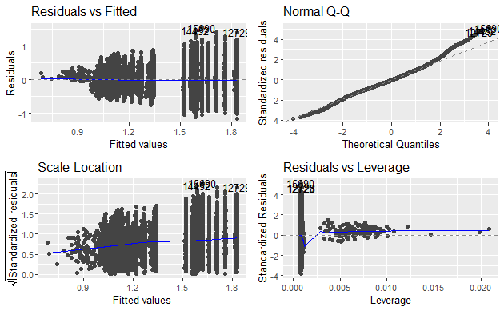

```r
autoplot(model_3_tot_vol)
```

#### Discussion

The total volume is again is shown to have residuals around 0 wiith a small change over the fitted values. The residuals are slightly right skewed. The p-value shows this variable is still significant

### plu_4

```r
model_3_plu4046 <- lm(average_price ~ type + month + plu_4046,
                   data = avocado_train)

summary(model_3_plu4046)
```

```
Call:
lm(formula = average_price ~ type + month + plu_4046, data = avocado_train)

Residuals:
     Min       1Q   Median       3Q      Max
-1.15012 -0.19568 -0.02006  0.18741  1.54589

Coefficients:
              Estimate Std. Error t value Pr(>|t|)
(Intercept)  1.179e+00  3.504e-03 336.515  < 2e-16 ***
typeorganic  4.843e-01  4.818e-03 100.522  < 2e-16 ***
month.L      2.129e-01  8.006e-03  26.595  < 2e-16 ***
month.Q     -1.545e-01  8.120e-03 -19.026  < 2e-16 ***
month.C     -1.869e-01  8.111e-03 -23.041  < 2e-16 ***
month^4     -7.269e-02  8.061e-03  -9.017  < 2e-16 ***
month^5     -1.099e-02  8.168e-03  -1.345 0.178566
month^6      6.124e-02  8.274e-03   7.401 1.41e-13 ***
month^7     -4.892e-03  8.095e-03  -0.604 0.545653
month^8      2.956e-02  8.122e-03   3.640 0.000274 ***
month^9      1.083e-02  8.335e-03   1.299 0.193838
month^10    -2.242e-02  8.373e-03  -2.677 0.007430 **
month^11     1.446e-02  8.425e-03   1.717 0.086047 .
plu_4046    -2.190e-08  1.920e-09 -11.408  < 2e-16 ***
---
Signif. codes:  0 ‘***’ 0.001 ‘**’ 0.01 ‘*’ 0.05 ‘.’ 0.1 ‘ ’ 1

Residual standard error: 0.3008 on 16411 degrees of freedom
Multiple R-squared:  0.4443,    Adjusted R-squared:  0.4438
F-statistic:  1009 on 13 and 16411 DF,  p-value: < 2.2e-16
```

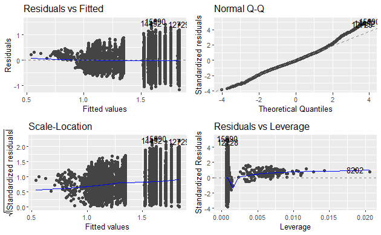

```r
autoplot(model_3_plu4046)
```

#### Discussion

Results are similar to the total_volume for the residuals. The r2 is slightly higher than the total_volume.

> champion is year

## Model 4

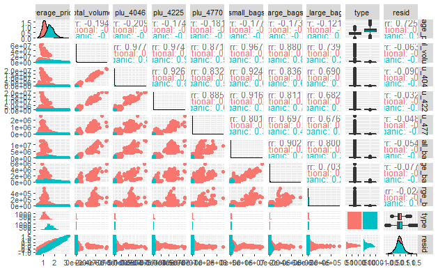

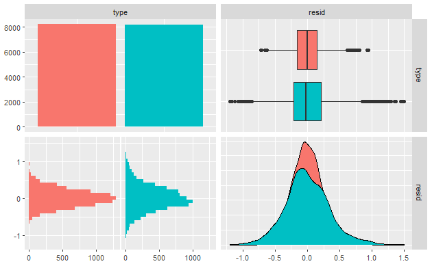

```r
avocado_train %>%
  add_residuals(model_3_year) %>%
  ggpairs_plots(main_columns = c("resid", "type"), remove_columns = c("month", "year"))
```

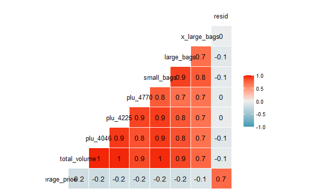

```r
avocado_train %>%
  add_residuals(model_3_year) %>%
  ggcorr(label = TRUE)
```

### plu_4046

```r
model_4_plu4046 <- lm(average_price ~ type + month + year + plu_4046,
                   data = avocado_train)

summary(model_4_plu4046)
```

```
Call:
lm(formula = average_price ~ type + month + year + plu_4046,
    data = avocado_train)

Residuals:
     Min       1Q   Median       3Q      Max
-1.20327 -0.18441 -0.01043  0.17783  1.49564

Coefficients:
              Estimate Std. Error t value Pr(>|t|)
(Intercept)  1.142e+00  4.830e-03 236.354  < 2e-16 ***
typeorganic  4.846e-01  4.665e-03 103.881  < 2e-16 ***
month.L      2.241e-01  8.171e-03  27.422  < 2e-16 ***
month.Q     -1.682e-01  8.040e-03 -20.922  < 2e-16 ***
month.C     -1.878e-01  7.858e-03 -23.892  < 2e-16 ***
month^4     -7.116e-02  7.844e-03  -9.072  < 2e-16 ***
month^5     -1.767e-02  7.959e-03  -2.220  0.02641 *
month^6      5.875e-02  8.022e-03   7.324 2.52e-13 ***
month^7     -3.089e-03  7.845e-03  -0.394  0.69382
month^8      2.338e-02  7.889e-03   2.964  0.00304 **
month^9      5.524e-03  8.098e-03   0.682  0.49512
month^10    -1.530e-02  8.122e-03  -1.883  0.05968 .
month^11     1.299e-02  8.160e-03   1.592  0.11140
year2016    -3.906e-02  5.814e-03  -6.718 1.91e-11 ***
year2017     1.398e-01  5.783e-03  24.180  < 2e-16 ***
year2018     8.557e-02  1.035e-02   8.269  < 2e-16 ***
plu_4046    -2.200e-08  1.859e-09 -11.834  < 2e-16 ***
---
Signif. codes:  0 ‘***’ 0.001 ‘**’ 0.01 ‘*’ 0.05 ‘.’ 0.1 ‘ ’ 1

Residual standard error: 0.2913 on 16408 degrees of freedom
Multiple R-squared:  0.4791,    Adjusted R-squared:  0.4786
F-statistic: 943.1 on 16 and 16408 DF,  p-value: < 2.2e-16
```

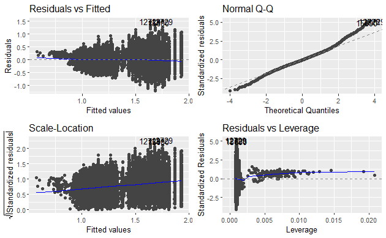

```r
autoplot(model_4_plu4046)
```

#### Discussion

[figure not shown]

### total_volume

```r
model_4_tot_vol <- lm(average_price ~ type + month + year + total_volume,
                   data = avocado_train)

summary(model_4_tot_vol)
```

```
Call:
lm(formula = average_price ~ type + month + year + total_volume,
    data = avocado_train)

Residuals:
     Min       1Q   Median       3Q      Max
-1.20327 -0.18573 -0.00984  0.17800  1.49452

Coefficients:
               Estimate Std. Error t value Pr(>|t|)
(Intercept)   1.138e+00  4.837e-03 235.188  < 2e-16 ***
typeorganic   4.881e-01  4.683e-03 104.217  < 2e-16 ***
month.L       2.249e-01  8.188e-03  27.469  < 2e-16 ***
month.Q      -1.675e-01  8.057e-03 -20.793  < 2e-16 ***
month.C      -1.882e-01  7.875e-03 -23.899  < 2e-16 ***
month^4      -7.153e-02  7.860e-03  -9.099  < 2e-16 ***
month^5      -1.769e-02  7.976e-03  -2.218  0.02656 *
month^6       5.922e-02  8.039e-03   7.367 1.83e-13 ***
month^7      -3.383e-03  7.862e-03  -0.430  0.66703
month^8       2.364e-02  7.906e-03   2.990  0.00279 **
month^9       5.586e-03  8.115e-03   0.688  0.49124
month^10     -1.552e-02  8.140e-03  -1.907  0.05659 .
month^11      1.287e-02  8.178e-03   1.574  0.11550
year2016     -3.796e-02  5.827e-03  -6.515 7.50e-11 ***
year2017      1.406e-01  5.796e-03  24.260  < 2e-16 ***
year2018      8.618e-02  1.037e-02   8.310  < 2e-16 ***
total_volume -5.665e-09  6.831e-10  -8.292  < 2e-16 ***
---
Signif. codes:  0 ‘***’ 0.001 ‘**’ 0.01 ‘*’ 0.05 ‘.’ 0.1 ‘ ’ 1

Residual standard error: 0.2919 on 16408 degrees of freedom
Multiple R-squared:  0.4768,    Adjusted R-squared:  0.4763
F-statistic: 934.6 on 16 and 16408 DF,  p-value: < 2.2e-16
```

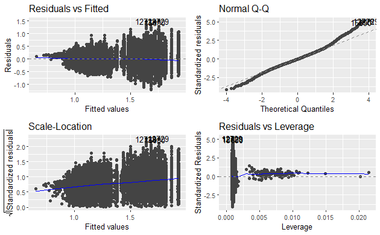

```r
autoplot(model_4_tot_vol)
```

[figure not shown]

```r
model_4_tot_vol_log <- lm(average_price ~ type + month + year + log(total_volume),
                   data = avocado_train)

summary(model_4_tot_vol_log)
```

```
Call:
lm(formula = average_price ~ type + month + year + log(total_volume),
    data = avocado_train)

Residuals:
     Min       1Q   Median       3Q      Max
-1.16916 -0.18327 -0.00627  0.17108  1.51056

Coefficients:
                    Estimate Std. Error t value Pr(>|t|)
(Intercept)        1.7303387  0.0214841  80.541  < 2e-16 ***
typeorganic        0.3261352  0.0074417  43.825  < 2e-16 ***
month.L            0.2196254  0.0080085  27.424  < 2e-16 ***
month.Q           -0.1766886  0.0078860 -22.405  < 2e-16 ***
month.C           -0.1817063  0.0077049 -23.583  < 2e-16 ***
month^4           -0.0682994  0.0076874  -8.885  < 2e-16 ***
month^5           -0.0175936  0.0078001  -2.256   0.0241 *
month^6            0.0581160  0.0078614   7.393 1.51e-13 ***
month^7           -0.0009961  0.0076889  -0.130   0.8969
month^8            0.0216560  0.0077318   2.801   0.0051 **
month^9            0.0045353  0.0079359   0.571   0.5677
month^10          -0.0141419  0.0079602  -1.777   0.0757 .
month^11           0.0112882  0.0079974   1.411   0.1581
year2016          -0.0252189  0.0057166  -4.411 1.03e-05 ***
year2017           0.1603658  0.0057109  28.081  < 2e-16 ***
year2018           0.1171107  0.0102026  11.479  < 2e-16 ***
log(total_volume) -0.0467601  0.0016308 -28.673  < 2e-16 ***
---
Signif. codes:  0 ‘***’ 0.001 ‘**’ 0.01 ‘*’ 0.05 ‘.’ 0.1 ‘ ’ 1

Residual standard error: 0.2854 on 16408 degrees of freedom
Multiple R-squared:  0.4997,    Adjusted R-squared:  0.4992
F-statistic:  1024 on 16 and 16408 DF,  p-value: < 2.2e-16
```

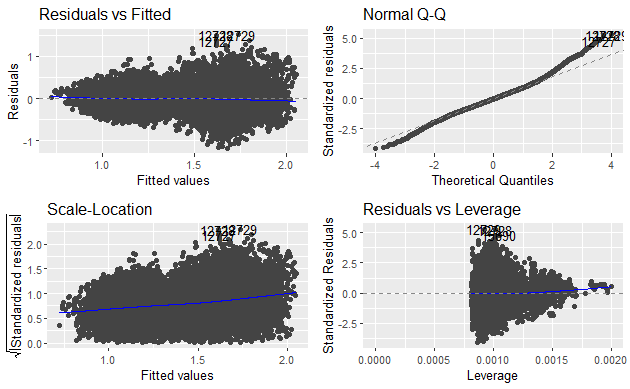

```r
autoplot(model_4_tot_vol_log)
```

```r
model_4_tot_vol_log <- lm(average_price ~ type + month + year + log(total_volume),
                   data = avocado_train)

summary(model_4_tot_vol_log)
```

```
Call:
lm(formula = average_price ~ type + month + year + log(total_volume),
    data = avocado_train)

Residuals:
     Min       1Q   Median       3Q      Max
-1.16916 -0.18327 -0.00627  0.17108  1.51056

Coefficients:
                    Estimate Std. Error t value Pr(>|t|)
(Intercept)        1.7303387  0.0214841  80.541  < 2e-16 ***
typeorganic        0.3261352  0.0074417  43.825  < 2e-16 ***
month.L            0.2196254  0.0080085  27.424  < 2e-16 ***
month.Q           -0.1766886  0.0078860 -22.405  < 2e-16 ***
month.C           -0.1817063  0.0077049 -23.583  < 2e-16 ***
month^4           -0.0682994  0.0076874  -8.885  < 2e-16 ***
month^5           -0.0175936  0.0078001  -2.256   0.0241 *
month^6            0.0581160  0.0078614   7.393 1.51e-13 ***
month^7           -0.0009961  0.0076889  -0.130   0.8969
month^8            0.0216560  0.0077318   2.801   0.0051 **
month^9            0.0045353  0.0079359   0.571   0.5677
month^10          -0.0141419  0.0079602  -1.777   0.0757 .
month^11           0.0112882  0.0079974   1.411   0.1581
year2016          -0.0252189  0.0057166  -4.411 1.03e-05 ***
year2017           0.1603658  0.0057109  28.081  < 2e-16 ***
year2018           0.1171107  0.0102026  11.479  < 2e-16 ***
log(total_volume) -0.0467601  0.0016308 -28.673  < 2e-16 ***
---
Signif. codes:  0 ‘***’ 0.001 ‘**’ 0.01 ‘*’ 0.05 ‘.’ 0.1 ‘ ’ 1

Residual standard error: 0.2854 on 16408 degrees of freedom
Multiple R-squared:  0.4997,    Adjusted R-squared:  0.4992
F-statistic:  1024 on 16 and 16408 DF,  p-value: < 2.2e-16
```

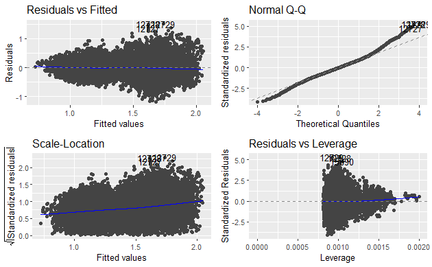

```r
autoplot(model_4_tot_vol_log)
```

#### Discussion

Taking the logarithmic has helped to distribute the residuals and has provided a better correlation. The Q-Q plot still has a similar result to the baseline value.

```r
model_4_plu4225 <- lm(average_price^0.5 ~ type + month + year + plu_4225,
                   data = avocado_train)

summary(model_4_plu4225)
```

```
Call:
lm(formula = average_price^0.5 ~ type + month + year + plu_4225,
    data = avocado_train)

Residuals:
     Min       1Q   Median       3Q      Max
-0.59637 -0.07563  0.00105  0.07957  0.49293

Coefficients:
              Estimate Std. Error t value Pr(>|t|)
(Intercept)  1.060e+00  2.020e-03 524.750  < 2e-16 ***
typeorganic  2.073e-01  1.949e-03 106.378  < 2e-16 ***
month.L      9.665e-02  3.407e-03  28.363  < 2e-16 ***
month.Q     -6.984e-02  3.353e-03 -20.830  < 2e-16 ***
month.C     -7.837e-02  3.277e-03 -23.916  < 2e-16 ***
month^4     -2.852e-02  3.271e-03  -8.718  < 2e-16 ***
month^5     -8.788e-03  3.319e-03  -2.648 0.008116 **
month^6      2.431e-02  3.345e-03   7.266 3.88e-13 ***
month^7     -4.456e-03  3.272e-03  -1.362 0.173227
month^8      1.121e-02  3.290e-03   3.407 0.000659 ***
month^9      3.443e-03  3.377e-03   1.019 0.308005
month^10    -6.441e-03  3.387e-03  -1.901 0.057258 .
month^11     5.044e-03  3.403e-03   1.482 0.138298
year2016    -1.786e-02  2.425e-03  -7.365 1.86e-13 ***
year2017     5.627e-02  2.412e-03  23.327  < 2e-16 ***
year2018     3.931e-02  4.316e-03   9.109  < 2e-16 ***
plu_4225    -3.712e-09  8.137e-10  -4.563 5.09e-06 ***
---
Signif. codes:  0 ‘***’ 0.001 ‘**’ 0.01 ‘*’ 0.05 ‘.’ 0.1 ‘ ’ 1

Residual standard error: 0.1215 on 16408 degrees of freedom
Multiple R-squared:  0.4811,    Adjusted R-squared:  0.4805
F-statistic: 950.6 on 16 and 16408 DF,  p-value: < 2.2e-16
```

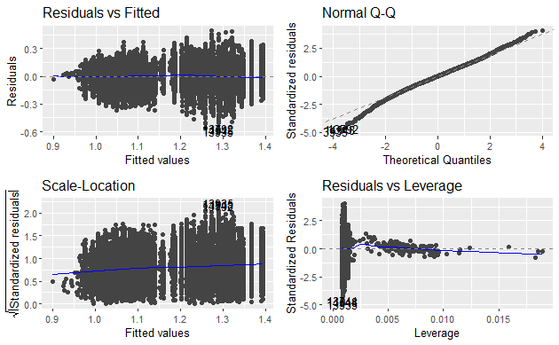

```r
autoplot(model_4_plu4225)
```

> Will use log(total_volume)

## Model 5

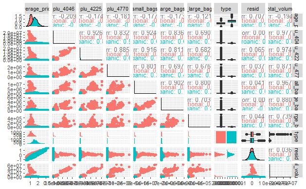

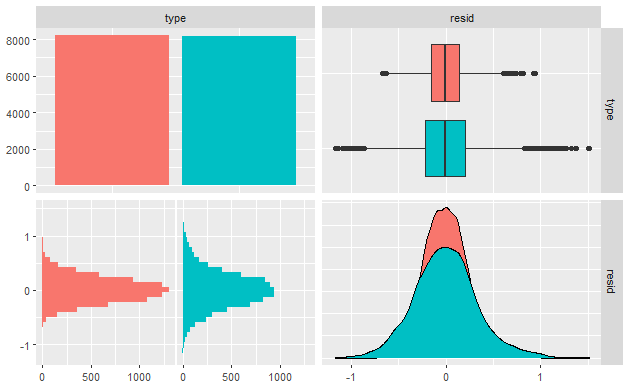

```r
avocado_train %>%
  add_residuals(model_4_tot_vol_log) %>%
  ggpairs_plots(main_columns = c("resid", "type"),
                remove_columns = c("month", "year", "total_volume"))
```

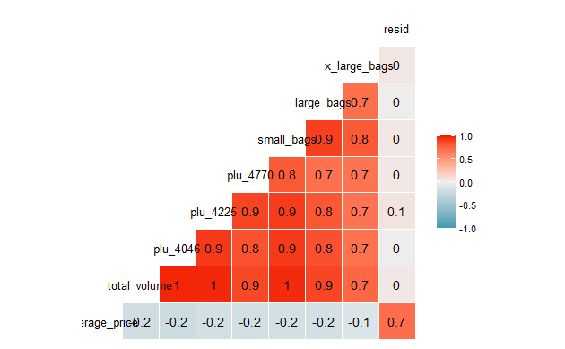

```r
avocado_train %>%
  add_residuals(model_4_tot_vol_log) %>%
  ggcorr(label = TRUE)
```

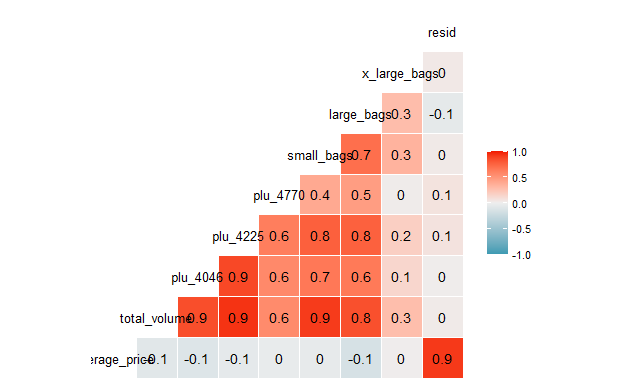

```r
avocado_train %>%
  filter(type == "organic") %>%
  add_residuals(model_4_tot_vol_log) %>%
  ggcorr(label = TRUE)
```

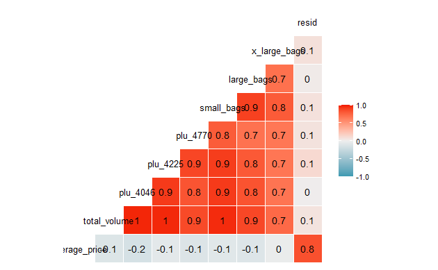

```r
avocado_train %>%
  filter(type != "organic") %>%
  add_residuals(model_4_tot_vol_log) %>%
  ggcorr(label = TRUE)
```

The correlation for all of the variables left with the residuals is still very small.

#### plu4225

```r
model_5_plu4225 <- lm(average_price ~ type + month + year + log(total_volume) +
                        plu_4225,
                   data = avocado_train)

summary(model_5_plu4225)
```

```
Call:
lm(formula = average_price ~ type + month + year + log(total_volume) +
    plu_4225, data = avocado_train)

Residuals:
    Min      1Q  Median      3Q     Max
-1.1688 -0.1825 -0.0067  0.1707  1.5131

Coefficients:
                    Estimate Std. Error t value Pr(>|t|)
(Intercept)        1.820e+00  2.335e-02  77.917  < 2e-16 ***
typeorganic        3.087e-01  7.639e-03  40.410  < 2e-16 ***
month.L            2.205e-01  7.987e-03  27.607  < 2e-16 ***
month.Q           -1.786e-01  7.867e-03 -22.702  < 2e-16 ***
month.C           -1.807e-01  7.684e-03 -23.516  < 2e-16 ***
month^4           -6.844e-02  7.666e-03  -8.928  < 2e-16 ***
month^5           -1.783e-02  7.779e-03  -2.292  0.02190 *
month^6            5.846e-02  7.840e-03   7.457 9.30e-14 ***
month^7           -1.452e-03  7.668e-03  -0.189  0.84985
month^8            2.122e-02  7.710e-03   2.752  0.00592 **
month^9            4.132e-03  7.914e-03   0.522  0.60161
month^10          -1.431e-02  7.938e-03  -1.803  0.07136 .
month^11           1.153e-02  7.975e-03   1.446  0.14830
year2016          -2.276e-02  5.706e-03  -3.989 6.66e-05 ***
year2017           1.647e-01  5.713e-03  28.835  < 2e-16 ***
year2018           1.232e-01  1.019e-02  12.085  < 2e-16 ***
log(total_volume) -5.465e-02  1.821e-03 -30.002  < 2e-16 ***
plu_4225           2.053e-08  2.135e-09   9.615  < 2e-16 ***
---
Signif. codes:  0 ‘***’ 0.001 ‘**’ 0.01 ‘*’ 0.05 ‘.’ 0.1 ‘ ’ 1

Residual standard error: 0.2846 on 16407 degrees of freedom
Multiple R-squared:  0.5025,    Adjusted R-squared:  0.502
F-statistic: 974.8 on 17 and 16407 DF,  p-value: < 2.2e-16
```

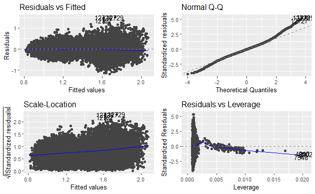

```r
autoplot(model_5_plu4225)
```

#### Discussion

The inclusion of plu_4225 does not affect the residual plots but does slightly increase the r2 value. The p-value is significant.

### plu_4770

```r
model_5_plu4770 <- lm(average_price ~ type + month + year + log(total_volume) +
                        plu_4770,
                   data = avocado_train)

summary(model_5_plu4770)
```

```
Call:
lm(formula = average_price ~ type + month + year + log(total_volume) +
    plu_4770, data = avocado_train)

Residuals:
     Min       1Q   Median       3Q      Max
-1.16919 -0.18321 -0.00627  0.17053  1.51207

Coefficients:
                    Estimate Std. Error t value Pr(>|t|)
(Intercept)        1.772e+00  2.286e-02  77.508  < 2e-16 ***
typeorganic        3.181e-01  7.587e-03  41.929  < 2e-16 ***
month.L            2.211e-01  8.007e-03  27.617  < 2e-16 ***
month.Q           -1.771e-01  7.880e-03 -22.473  < 2e-16 ***
month.C           -1.818e-01  7.699e-03 -23.614  < 2e-16 ***
month^4           -6.830e-02  7.681e-03  -8.892  < 2e-16 ***
month^5           -1.762e-02  7.794e-03  -2.261  0.02380 *
month^6            5.863e-02  7.855e-03   7.463 8.88e-14 ***
month^7           -1.245e-03  7.683e-03  -0.162  0.87124
month^8            2.110e-02  7.726e-03   2.731  0.00632 **
month^9            4.320e-03  7.929e-03   0.545  0.58590
month^10          -1.397e-02  7.954e-03  -1.757  0.07897 .
month^11           1.123e-02  7.991e-03   1.405  0.15998
year2016          -2.464e-02  5.713e-03  -4.312 1.63e-05 ***
year2017           1.632e-01  5.730e-03  28.473  < 2e-16 ***
year2018           1.212e-01  1.022e-02  11.858  < 2e-16 ***
log(total_volume) -5.047e-02  1.772e-03 -28.471  < 2e-16 ***
plu_4770           1.222e-07  2.301e-08   5.312 1.10e-07 ***
---
Signif. codes:  0 ‘***’ 0.001 ‘**’ 0.01 ‘*’ 0.05 ‘.’ 0.1 ‘ ’ 1

Residual standard error: 0.2852 on 16407 degrees of freedom
Multiple R-squared:  0.5005,    Adjusted R-squared:    0.5
F-statistic: 967.2 on 17 and 16407 DF,  p-value: < 2.2e-16
```

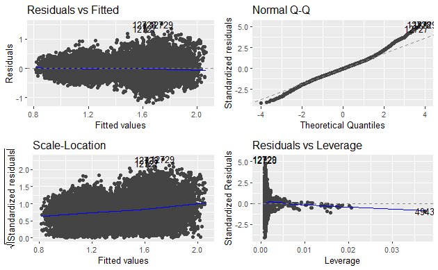

```r
autoplot(model_5_plu4770)
```

#### Discussion

Again there is limited change to the residual plots and is therefore acceptable. The r2 does increase however not as much as plu_40225.

> Will use plu_40225

## Model 6

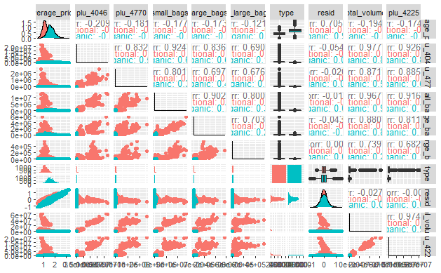

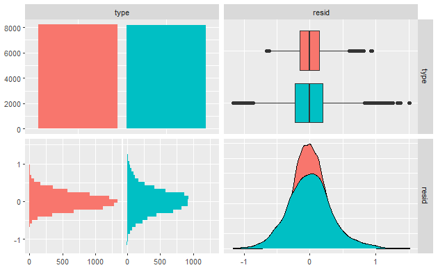

```r
avocado_train %>%
  add_residuals(model_5_plu4225) %>%
  ggpairs_plots(main_columns = c("resid", "type"),
                remove_columns = c("month", "year", "total_volume", "plu_4225"))
```

### interaction with total_volume

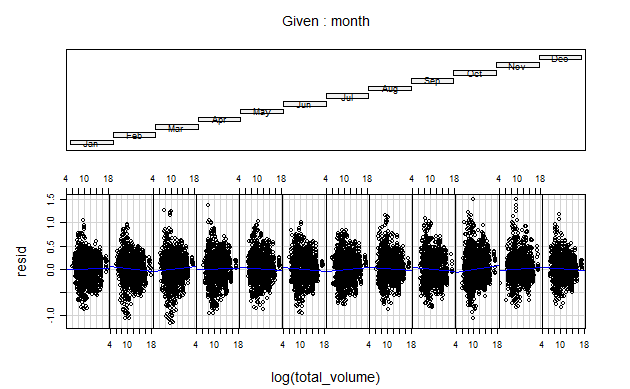

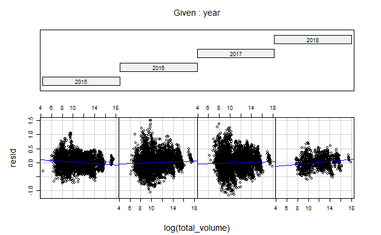

```r
coplot(resid ~ log(total_volume) | year,
       panel = function(x, y, ...){
         points(x, y)
         abline(lm(y ~ x), col = "blue")
       },
       data = avocado_train %>% add_residuals(model_4_tot_vol_log), rows = 1)
```

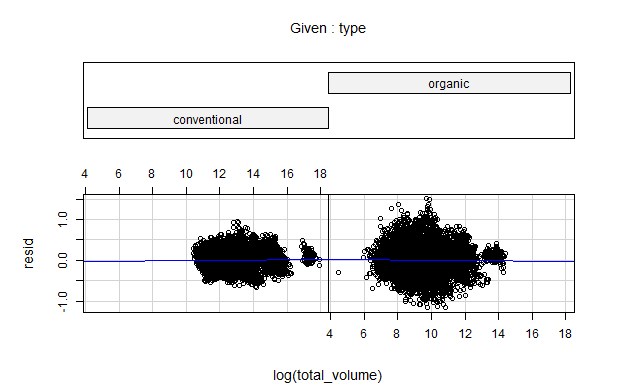

```r
coplot(resid ~ log(total_volume) | type,
       panel = function(x, y, ...){
         points(x, y)
         abline(lm(y ~ x), col = "blue")
       },
       data = avocado_train %>% add_residuals(model_4_tot_vol_log), rows = 1)
```

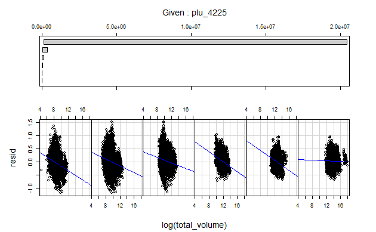

#### Discussion

The interactions between most seem minor. The most effected appear to be year and plu_4225

### Interactions with plu_4225

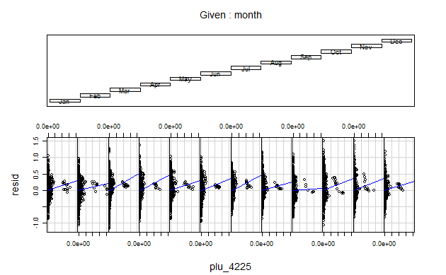

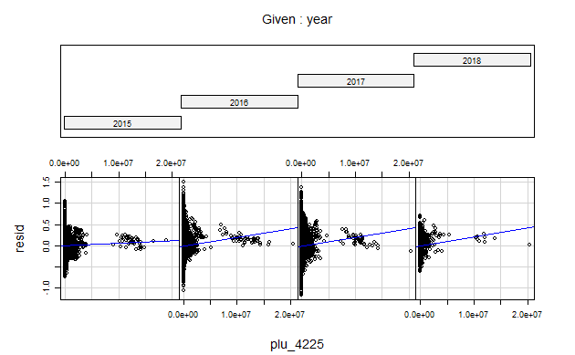

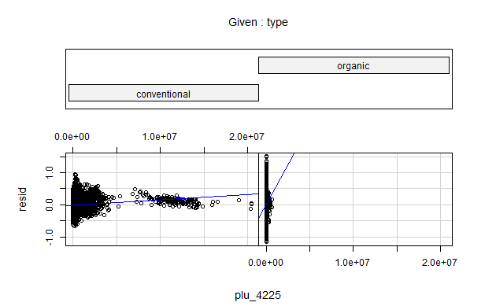

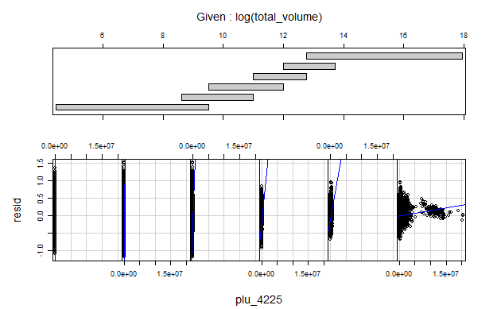

#### Discussion

From the plots, the interaction between total volume and plu_4225 has the largest impact.

```r
model_6_vol_4225 <- lm(average_price ~ type + month + year + log(total_volume) +
                        plu_4225 + log(total_volume):plu_4225,
                       data = avocado_train)

summary(model_6_vol_4225)
```

```
Call:
lm(formula = average_price ~ type + month + year + log(total_volume) +
    plu_4225 + log(total_volume):plu_4225, data = avocado_train)

Residuals:
     Min       1Q   Median       3Q      Max
-1.16557 -0.17684 -0.00565  0.16541  1.51861

Coefficients:
                             Estimate Std. Error t value Pr(>|t|)
(Intercept)                 1.999e+00  2.473e-02  80.810  < 2e-16 ***
typeorganic                 2.956e-01  7.575e-03  39.019  < 2e-16 ***
month.L                     2.226e-01  7.891e-03  28.212  < 2e-16 ***
month.Q                    -1.828e-01  7.775e-03 -23.509  < 2e-16 ***
month.C                    -1.775e-01  7.593e-03 -23.370  < 2e-16 ***
month^4                    -6.756e-02  7.574e-03  -8.921  < 2e-16 ***
month^5                    -1.880e-02  7.685e-03  -2.446  0.01444 *
month^6                     5.776e-02  7.745e-03   7.458 9.24e-14 ***
month^7                    -2.418e-03  7.575e-03  -0.319  0.74956
month^8                     2.095e-02  7.618e-03   2.750  0.00596 **
month^9                     3.794e-03  7.819e-03   0.485  0.62751
month^10                   -1.468e-02  7.842e-03  -1.871  0.06133 .
month^11                    1.227e-02  7.879e-03   1.557  0.11949
year2016                   -1.501e-02  5.651e-03  -2.657  0.00790 **
year2017                    1.782e-01  5.684e-03  31.353  < 2e-16 ***
year2018                    1.415e-01  1.011e-02  13.996  < 2e-16 ***
log(total_volume)          -7.345e-02  2.028e-03 -36.213  < 2e-16 ***
plu_4225                    1.039e-06  5.073e-08  20.479  < 2e-16 ***
log(total_volume):plu_4225 -5.859e-08  2.916e-09 -20.091  < 2e-16 ***
---
Signif. codes:  0 ‘***’ 0.001 ‘**’ 0.01 ‘*’ 0.05 ‘.’ 0.1 ‘ ’ 1

Residual standard error: 0.2812 on 16406 degrees of freedom
Multiple R-squared:  0.5144,    Adjusted R-squared:  0.5139
F-statistic: 965.6 on 18 and 16406 DF,  p-value: < 2.2e-16
```

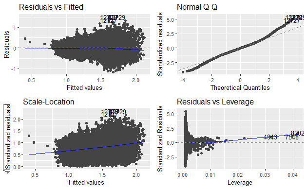

```r
autoplot(model_6_vol_4225)
```

```r
model_6_vol_month <- lm(average_price ~ type + month + year + log(total_volume) +
                        plu_4225 + log(total_volume):month,
                       data = avocado_train)

summary(model_6_vol_month)
```

```
Call:
lm(formula = average_price ~ type + month + year + log(total_volume) +
    plu_4225 + log(total_volume):month, data = avocado_train)

Residuals:
     Min       1Q   Median       3Q      Max
-1.15588 -0.18129 -0.00675  0.16968  1.52851

Coefficients:
                             Estimate Std. Error t value Pr(>|t|)
(Intercept)                 1.821e+00  2.337e-02  77.930  < 2e-16 ***
typeorganic                 3.087e-01  7.633e-03  40.440  < 2e-16 ***
month.L                     1.826e-01  3.802e-02   4.803 1.58e-06 ***
month.Q                    -1.876e-01  3.849e-02  -4.874 1.11e-06 ***
month.C                    -1.614e-01  3.871e-02  -4.168 3.09e-05 ***
month^4                     2.803e-02  3.830e-02   0.732  0.46426
month^5                     6.310e-02  3.889e-02   1.622  0.10474
month^6                     3.547e-02  3.947e-02   0.899  0.36885
month^7                     8.484e-02  3.863e-02   2.196  0.02808 *
month^8                    -1.216e-01  3.886e-02  -3.130  0.00175 **
month^9                    -6.592e-02  4.006e-02  -1.646  0.09988 .
month^10                   -1.676e-02  4.025e-02  -0.416  0.67716
month^11                    6.955e-02  4.017e-02   1.732  0.08337 .
year2016                   -2.257e-02  5.703e-03  -3.957 7.62e-05 ***
year2017                    1.648e-01  5.709e-03  28.865  < 2e-16 ***
year2018                    1.232e-01  1.021e-02  12.074  < 2e-16 ***
log(total_volume)          -5.478e-02  1.823e-03 -30.043  < 2e-16 ***
plu_4225                    2.078e-08  2.137e-09   9.723  < 2e-16 ***
month.L:log(total_volume)   3.379e-03  3.310e-03   1.021  0.30736
month.Q:log(total_volume)   8.086e-04  3.339e-03   0.242  0.80868
month.C:log(total_volume)  -1.747e-03  3.362e-03  -0.520  0.60335
month^4:log(total_volume)  -8.609e-03  3.326e-03  -2.588  0.00966 **
month^5:log(total_volume)  -7.241e-03  3.375e-03  -2.146  0.03193 *
month^6:log(total_volume)   1.946e-03  3.427e-03   0.568  0.57008
month^7:log(total_volume)  -7.515e-03  3.351e-03  -2.243  0.02493 *
month^8:log(total_volume)   1.263e-02  3.371e-03   3.746  0.00018 ***
month^9:log(total_volume)   6.246e-03  3.474e-03   1.798  0.07223 .
month^10:log(total_volume)  2.627e-04  3.482e-03   0.075  0.93988
month^11:log(total_volume) -5.115e-03  3.466e-03  -1.476  0.14010
---
Signif. codes:  0 ‘***’ 0.001 ‘**’ 0.01 ‘*’ 0.05 ‘.’ 0.1 ‘ ’ 1

Residual standard error: 0.2844 on 16396 degrees of freedom
Multiple R-squared:  0.5037,    Adjusted R-squared:  0.5028
F-statistic: 594.2 on 28 and 16396 DF,  p-value: < 2.2e-16
```

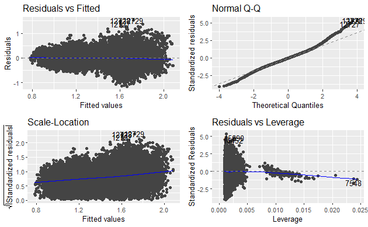

```r
autoplot(model_6_vol_month)
```

```r
model_6_4225_year <- lm(average_price ~ type + month + year + log(total_volume) +
                        plu_4225 + plu_4225:year,
                       data = avocado_train)

summary(model_6_4225_year)
```

```
Call:
lm(formula = average_price ~ type + month + year + log(total_volume) +
    plu_4225 + plu_4225:year, data = avocado_train)

Residuals:
     Min       1Q   Median       3Q      Max
-1.16752 -0.18217 -0.00606  0.17045  1.51398

Coefficients:
                    Estimate Std. Error t value Pr(>|t|)
(Intercept)        1.822e+00  2.336e-02  77.996  < 2e-16 ***
typeorganic        3.090e-01  7.638e-03  40.453  < 2e-16 ***
month.L            2.208e-01  7.985e-03  27.656  < 2e-16 ***
month.Q           -1.789e-01  7.865e-03 -22.741  < 2e-16 ***
month.C           -1.810e-01  7.682e-03 -23.561  < 2e-16 ***
month^4           -6.868e-02  7.664e-03  -8.961  < 2e-16 ***
month^5           -1.777e-02  7.776e-03  -2.286 0.022278 *
month^6            5.860e-02  7.838e-03   7.477 7.98e-14 ***
month^7           -1.325e-03  7.665e-03  -0.173 0.862752
month^8            2.127e-02  7.708e-03   2.760 0.005790 **
month^9            4.047e-03  7.912e-03   0.511 0.609032
month^10          -1.430e-02  7.936e-03  -1.802 0.071487 .
month^11           1.151e-02  7.973e-03   1.443 0.148963
year2016          -2.702e-02  5.872e-03  -4.602 4.22e-06 ***
year2017           1.605e-01  5.873e-03  27.335  < 2e-16 ***
year2018           1.187e-01  1.045e-02  11.357  < 2e-16 ***
log(total_volume) -5.461e-02  1.821e-03 -29.983  < 2e-16 ***
plu_4225           1.124e-08  3.342e-09   3.363 0.000772 ***
year2016:plu_4225  1.387e-08  4.548e-09   3.050 0.002296 **
year2017:plu_4225  1.424e-08  4.846e-09   2.938 0.003308 **
year2018:plu_4225  1.479e-08  7.311e-09   2.024 0.043004 *
---
Signif. codes:  0 ‘***’ 0.001 ‘**’ 0.01 ‘*’ 0.05 ‘.’ 0.1 ‘ ’ 1

Residual standard error: 0.2846 on 16404 degrees of freedom
Multiple R-squared:  0.5029,    Adjusted R-squared:  0.5023
F-statistic: 829.7 on 20 and 16404 DF,  p-value: < 2.2e-16
```

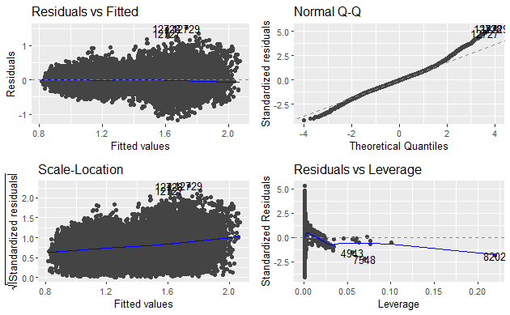

```r
autoplot(model_6_4225_year)
```

From the plots, again there is minimal change with the inclusion of this interaction. The interaction of plu_4225 and tota_volume does appear to be statistically significant.

> Interaction between plu_4225 and total_volume will be added.

# Model review

```r
relaimpo::calc.relimp(model_6_vol_4225, type = "lmg", rela = TRUE)
```

[output not shown]

| r.squared | adj.r.squared | sigma | statistic | p.value | df | logLik | AIC | BIC | deviance | df.residual | nobs |
| --- | --- | --- | --- | --- | --- | --- | --- | --- | --- | --- | --- |
| 0.5144373 | 0.5139045 | 0.281217 | 965.6446 | 0 | 18 | -2459.333 | 4958.666 | 5112.797 | 1297.436 | 16406 | 16425 |

```r
  mean((predictions_test$pred - avocado_test$average_price)^2)
```

```
[1] 0.07589605
```

| r.squared | adj.r.squared | sigma | statistic | p.value | df | logLik | AIC | BIC | deviance | df.residual | nobs |
| --- | --- | --- | --- | --- | --- | --- | --- | --- | --- | --- | --- |
| 0.5630694 | 0.5613333 | 0.2671456 | 324.3343 | 0 | 65 | -1592.634 | 3319.268 | 3835.608 | 1167.489 | 16359 | 16425 |

```r
glmulti_pred <- avocado_test %>%
  add_predictions(glmulti_model)
```

```r
mean((glmulti_pred$pred - avocado_test$average_price)^2)
```

```
[1] 0.06937901
```

### Summary

```r
summary(model_6_vol_4225)
```

```
Call:
lm(formula = average_price ~ type + month + year + log(total_volume) +
    plu_4225 + log(total_volume):plu_4225, data = avocado_train)

Residuals:
     Min       1Q   Median       3Q      Max
-1.16557 -0.17684 -0.00565  0.16541  1.51861

Coefficients:
                             Estimate Std. Error t value Pr(>|t|)
(Intercept)                 1.999e+00  2.473e-02  80.810  < 2e-16 ***
typeorganic                 2.956e-01  7.575e-03  39.019  < 2e-16 ***
month.L                     2.226e-01  7.891e-03  28.212  < 2e-16 ***
month.Q                    -1.828e-01  7.775e-03 -23.509  < 2e-16 ***
month.C                    -1.775e-01  7.593e-03 -23.370  < 2e-16 ***
month^4                    -6.756e-02  7.574e-03  -8.921  < 2e-16 ***
month^5                    -1.880e-02  7.685e-03  -2.446  0.01444 *
month^6                     5.776e-02  7.745e-03   7.458 9.24e-14 ***
month^7                    -2.418e-03  7.575e-03  -0.319  0.74956
month^8                     2.095e-02  7.618e-03   2.750  0.00596 **
month^9                     3.794e-03  7.819e-03   0.485  0.62751
month^10                   -1.468e-02  7.842e-03  -1.871  0.06133 .
month^11                    1.227e-02  7.879e-03   1.557  0.11949
year2016                   -1.501e-02  5.651e-03  -2.657  0.00790 **
year2017                    1.782e-01  5.684e-03  31.353  < 2e-16 ***
year2018                    1.415e-01  1.011e-02  13.996  < 2e-16 ***
log(total_volume)          -7.345e-02  2.028e-03 -36.213  < 2e-16 ***
plu_4225                    1.039e-06  5.073e-08  20.479  < 2e-16 ***
log(total_volume):plu_4225 -5.859e-08  2.916e-09 -20.091  < 2e-16 ***
---
Signif. codes:  0 ‘***’ 0.001 ‘**’ 0.01 ‘*’ 0.05 ‘.’ 0.1 ‘ ’ 1

Residual standard error: 0.2812 on 16406 degrees of freedom
Multiple R-squared:  0.5144,    Adjusted R-squared:  0.5139
F-statistic: 965.6 on 18 and 16406 DF,  p-value: < 2.2e-16
```